# Ambient-noise models for gRNA guide assignment: fishash, fishash+, and CLEANSER

# 9 Per-cell ambient depth

The core quantity each method needs is the cell’s ambient depth $d_c$ — the exposure a count is tested against. Critically, this is the depth each method **actually uses**, which is not the same across methods: **fishash uses the raw library size** $N_{:,c}$ (it computes a rank-1 field, but only for the guide-margin Simpson correction — the cell exposure it tests against is the raw library); **fishash+ uses the denoised rank-1 depth** $\hat d_c$; **CLEANSER uses $L_i$, the sum of the cell’s ≤2 counts**. These three can differ by orders of magnitude.

## 9.1 Distributions of depth used

`{r depth-dist, fig.height=8} dl <- depths %>% pivot_longer(c(fishash,fishashplus,cleanser), names_to="method", values_to="depth") %>% mutate(method=recode(method, fishashplus="fishash+"), dataset=fct(dataset)) %>% filter(depth>0) ggplot(dl, aes(depth, colour=method)) + geom_density(linewidth=0.6) + facet_wrap(~dataset, scales="free", ncol=4) + scale_x_log10() + scale_colour_manual(values=cols3) + labs(x="per-cell ambient depth USED d_c (log scale)", y="density", colour=NULL, title="Per-cell ambient depth USED, by method and dataset") + theme_bw(base_size=10) + theme(legend.position="top")`

**fishash’s raw-library depth (grey) is inflated far above the other two** — often 5–400× (e.g. barnyard_mch2_72hr median 1664 vs ~4; DC-TAP high-MOI 1860 vs 116 vs 43) — because the raw library is dominated by the cell’s own real integrations, exactly the signal a cell-margin should *exclude*. fishash+ (rank-1) and CLEANSER (≤2) are much closer to each other and to the true ambient scale; they pull apart only in the **deep direct-capture** datasets, where CLEANSER’s ≤2 cap discards genuine ambient UMIs (rank-1 > ≤2).

## 9.2 fishash+ (rank-1) vs CLEANSER (≤2) depth

`{r depth-scatter, fig.height=8} set.seed(1) ds_s <- depths %>% filter(fishashplus>0, cleanser>0) %>% group_by(dataset) %>% slice_sample(n=2500) %>% ungroup() %>% mutate(dataset=fct(dataset)) rr <- depths %>% filter(fishashplus>0,cleanser>0) %>% group_by(dataset) %>% summarize(r=cor(log10(fishashplus),log10(cleanser)), .groups="drop") labr <- setNames(sprintf("%s (r=%.2f)", rr$dataset, rr$r), rr$dataset) ggplot(ds_s, aes(fishashplus, cleanser)) + geom_abline(slope=1, intercept=0, linetype="dashed", colour="grey55") + geom_point(alpha=0.15, size=0.3, colour="#c0392b") + facet_wrap(~dataset, scales="free", ncol=4, labeller=labeller(dataset=labr)) + scale_x_log10() + scale_y_log10() + labs(x="fishash+ ambient depth d_c (rank-1)", y="CLEANSER ambient depth (sum of ≤2 UMIs)", title="Per-cell ambient depth: fishash+ vs CLEANSER", subtitle="Dashed = y=x. Below the line = CLEANSER underestimates depth (its ≤2 cap discards ambient UMIs >2).") + theme_bw(base_size=10)`

```r
dsum %>% arrange(desc(med_lib)) %>% transmute(dataset,
    `fishash (raw lib)`=round(med_depth_fishash,1), `fishash+ (rank-1)`=round(med_depth_fishashplus,1),
    `CLEANSER (≤2)`=round(med_depth_cleanser,1), `spearman(f+ , CLEANSER)`=round(spearman_fp_clns,3)) %>%
  kable(caption="Median per-cell ambient depth USED by each method. fishash's raw library is far larger than the denoised depths (it is inflated by the cell's own signal); fishash+ (rank-1) and CLEANSER (≤2) agree in rank (high Spearman) but the ≤2 magnitude collapses in the deepest datasets.")
```

# 10 Ambient cells at each gRNA count

A second view: at each gRNA UMI count $k$, what fraction of the (guide, cell) observations does each method leave as **ambient** (unassigned)? At $k=1$–2 essentially everything is ambient; as $k$ grows, real integrations appear and the ambient fraction should fall. The methods differ sharply in *where* it falls:

- **fishash** keeps a long ambient tail — in deep cells its inflated exposure leaves even large counts unassigned (self-masking).
- **fishash+** cuts the ambient fraction to ~0 much sooner.
- **CLEANSER**, by construction, treats counts ≤2 as ambient and >2 as candidate signal — effectively a step at $k=2$ (shown as a dashed reference; where the MCMC assignment is available, its empirical curve is drawn too).

`{r ambient-frac, fig.height=8} af <- afrac %>% mutate(frac=n_ambient/n_total) %>% select(dataset,k,method,frac) # CLEANSER empirical ambient fraction where the MCMC assignment is available (load counts to get k) clns_af <- list() for (ds in intersect(clns_ready, names(dataset_paths()))) { Ac <- tryCatch(load_clns(ds), error=function(e) NULL); if(is.null(Ac)) next ct <- as(load_counts(ds),"TsparseMatrix"); i<-ct@i+1L; j<-ct@j+1L; y<-as.numeric(ct@x) a <- as.logical(Ac[cbind(i,j)]); a[is.na(a)]<-FALSE; kk<-pmin(y,Kmax) tot<-tapply(rep(1,length(kk)),kk,sum); amb<-tapply(!a,kk,sum) clns_af[[ds]]<-data.frame(dataset=ds,k=as.integer(names(tot)),method="CLEANSER",frac=as.numeric(amb)/as.numeric(tot)) } clns_df <- if(length(clns_af)) do.call(rbind,clns_af) else NULL # CLEANSER (<=2 rule) reference for ALL datasets rule <- af %>% distinct(dataset,k) %>% mutate(method="CLEANSER (≤2 rule)", frac=ifelse(k<=2,1,0)) plotdf <- bind_rows(af, clns_df, rule) %>% mutate(dataset=fct(dataset), method=factor(method, levels=c("fishash","fishash+","CLEANSER","CLEANSER (≤2 rule)"))) ggplot(plotdf, aes(k, frac, colour=method, linetype=method)) + geom_line(linewidth=0.6) + facet_wrap(~dataset, scales="free_x", ncol=4) + scale_colour_manual(values=c("fishash"="#7f8c8d","fishash+"="#c0392b","CLEANSER"="#2980b9","CLEANSER (≤2 rule)"="#2980b9")) + scale_linetype_manual(values=c("fishash"=1,"fishash+"=1,"CLEANSER"=1,"CLEANSER (≤2 rule)"=3)) + labs(x="gRNA UMI count k", y="fraction of observations at count k left ambient", colour=NULL, linetype=NULL, title="Where does each method stop calling counts 'ambient'?", subtitle="Fraction of (guide,cell) observations at each count left unassigned. fishash keeps a long tail; fishash+ cuts sooner; CLEANSER (solid where MCMC ran; dotted = ≤2 rule) caps near 2.") + theme_bw(base_size=10) + theme(legend.position="top")`

## 10.1 Per-guide ambient ceiling: fishash vs fishash+

The **ambient ceiling** of a guide is the largest count a method still leaves unassigned. fishash’s ceilings run into the hundreds/thousands on deep data (it fails to assign genuine strong integrations); fishash+’s are far lower.

`{r ceiling-scatter, fig.height=7} cc <- ceil %>% filter(is.finite(ceil_fishash), is.finite(ceil_fishashplus)) %>% mutate(dataset=fct(dataset)) ggplot(cc, aes(ceil_fishash, ceil_fishashplus)) + geom_abline(slope=1,intercept=0,linetype="dashed",colour="grey55") + geom_jitter(width=0.1,height=0.1,alpha=0.3,size=0.5,colour="#8e44ad") + facet_wrap(~dataset, scales="free", ncol=4) + scale_x_log10() + scale_y_log10() + labs(x="ambient ceiling (fishash)", y="ambient ceiling (fishash+)", title="Per-guide ambient ceiling: fishash vs fishash+", subtitle="Below the line = fishash+ assigns as signal what fishash still calls ambient (recovers self-masked integrations).") + theme_bw(base_size=10)`

# 11 Per-guide view: which counts each method calls ambient

Zooming into individual guides makes the differences concrete. Using the DC-TAP positive-control guides (targeting GATA1, HDAC6, MYC), we plot the observed gRNA-count histogram (grey bars) and, for each count bin, the **number of those cells each method leaves ambient** (unassigned). Where a line rides along the top of the bars, the method is calling that count ambient; where it drops below the bars, it is assigning those cells as real signal.

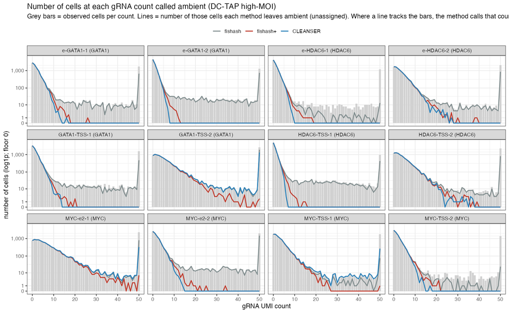

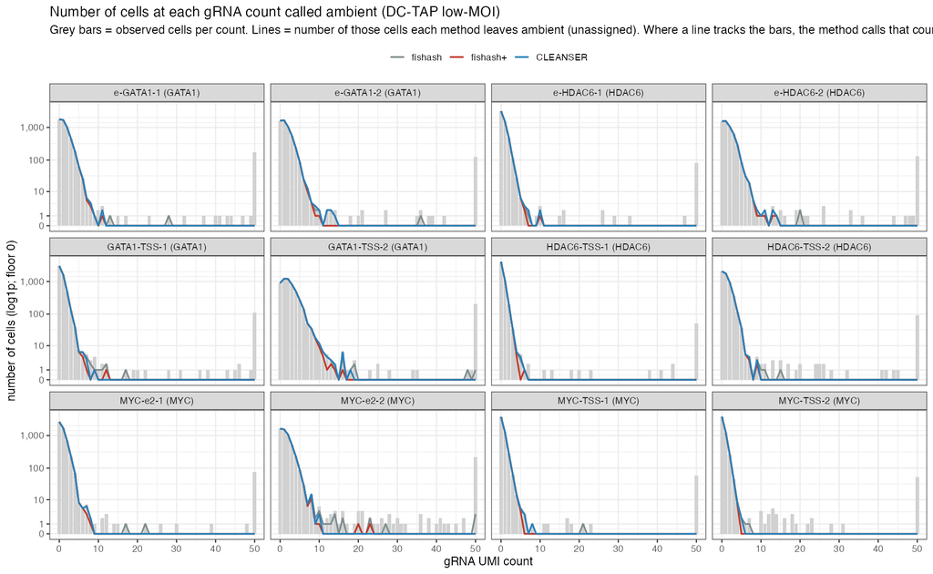

DC-TAP **low-MOI**. With cells carrying ~one guide, the three methods largely agree — all of them pull away from the bars at moderate counts, so far fewer high-count cells are left ambient. The divergence above is a high-MOI/high-depth phenomenon.

At **high MOI** the three separate cleanly:

At **low MOI** the three largely coincide: with roughly one guide per cell there is little co-occurring signal to inflate a cell’s depth, so all three assign the high-count cells.

# 12 Assignment agreement

How much do the three methods actually agree on which (guide, cell) pairs are real? We measure the **Jaccard similarity** of their assigned-entry sets.

## 12.1 fishash vs fishash+ (all datasets)

```r
jf <- jff %>% mutate(dataset=fct(dataset)) %>% arrange(jaccard)
ggplot(jf, aes(jaccard, reorder(dataset, jaccard))) +
  geom_col(fill="#8e44ad") +
  geom_text(aes(label=sprintf("%.2f", jaccard)), hjust=-0.1, size=3) +
  coord_cartesian(xlim=c(min(0.5,min(jf$jaccard)*0.95),1.03)) +
  labs(x="Jaccard(fishash, fishash+)", y=NULL,
       title="fishash vs fishash+ assignment agreement",
       subtitle="Lower = the depth-fix changes more assignments (bigger recall gain). Note x-axis truncated.") +
  theme_bw(base_size=11)
```

## 12.2 Three-way agreement (datasets with CLEANSER assignments)

`` {r threeway, fig.height=6} avail <- intersect(clns_ready, ord) jac <- function(A,B) { i<-sum(A&B); u<-sum(A|B); if(u>0) i/u else NA } rows <- list() for (ds in avail) { Af<-readRDS(file.path(AS,paste0(ds,"_fishash.rds"))) Ap<-readRDS(file.path(AS,paste0(ds,"_fishashplus.rds"))) Ac<-tryCatch(load_clns(ds),error=function(e) NULL); if(is.null(Ac)) next M<-list(fishash=Af,`fishash+`=Ap,CLEANSER=Ac) for(a in names(M)) for(b in names(M)) rows[[length(rows)+1]]<- data.frame(dataset=ds,m1=a,m2=b,jaccard=jac(M[[a]],M[[b]])) } if (length(rows)) { J <- do.call(rbind, rows) J$m1<-factor(J$m1,levels=c("fishash","fishash+","CLEANSER")); J$m2<-factor(J$m2,levels=rev(c("fishash","fishash+","CLEANSER"))) ggplot(J, aes(m1,m2,fill=jaccard)) + geom_tile(colour="white") + geom_text(aes(label=sprintf("%.2f",jaccard)), size=3) + facet_wrap(~dataset) + scale_fill_gradient(low="#fff5eb", high="#7f2704", limits=c(0,1)) + labs(x=NULL,y=NULL,title="Pairwise Jaccard among the three methods", subtitle="Assigned-entry overlap. Datasets shown are those where CLEANSER MCMC has finished.") + theme_minimal(base_size=11) } else { cat("CLEANSER assignments not yet available for any dataset — three-way panel pending MCMC.") } ``

## 12.3 Who assigns what the others don’t?

Among (guide, cell) pairs assigned by **at least one** method, how many are agreed on by all three, and how many are unique to a single method? A method whose “unique” calls are real integrations is adding recall; one whose unique calls are noise is over-assigning.

```r
rows2 <- list()
for (ds in avail) {
  Af<-readRDS(file.path(AS,paste0(ds,"_fishash.rds")))
  Ap<-readRDS(file.path(AS,paste0(ds,"_fishashplus.rds")))
  Ac<-tryCatch(load_clns(ds),error=function(e) NULL); if(is.null(Ac)) next
  U <- (Af|Ap|Ac); u<-as(U,"TsparseMatrix"); i<-u@i+1L; j<-u@j+1L
  a<-as.logical(Af[cbind(i,j)]); b<-as.logical(Ap[cbind(i,j)]); cc2<-as.logical(Ac[cbind(i,j)])
  rows2[[ds]]<-data.frame(dataset=ds, n_union=length(i), frac_all=mean(a&b&cc2),
                          only_fishash=mean(a&!b&!cc2), only_fplus=mean(!a&b&!cc2), only_clns=mean(!a&!b&cc2),
                          fplus_clns_not_fishash=mean(!a&b&cc2))
}
if (length(rows2)) {
  S2<-do.call(rbind,rows2)
  kable(S2 %>% transmute(dataset, `union entries`=n_union,
     `all 3`=round(frac_all,3), `fishash only`=round(only_fishash,3),
     `fishash+ only`=round(only_fplus,3), `CLEANSER only`=round(only_clns,3),
     `f+ & CLNS, not fishash`=round(fplus_clns_not_fishash,3)),
     caption="Fraction of the union of assigned entries falling in each agreement class. 'f+ & CLNS, not fishash' = the self-masked integrations both cell-margin-decontaminated methods recover but fishash misses.")
} else cat("_CLEANSER MCMC assignments not yet available — three-way tables will populate as the batch completes; re-render to update._")
```

# 13 Recall / assignment counts

```r
ac <- acount %>% transmute(dataset, fishash, `fishash+`=fishashplus,
        `fishash+ vs fishash`=sprintf("+%.0f%%", 100*(fishashplus-fishash)/fishash)) %>%
  left_join(dsum %>% select(dataset, med_lib), by="dataset") %>% arrange(desc(med_lib)) %>% select(-med_lib)
kable(ac, caption="Total assigned (guide,cell) pairs per method. fishash+ consistently assigns more — the recovered self-masked integrations.")
```

# 14 Takeaways

*Next step (separate analysis): feed each method’s assignments into SCEPTRE and compare downstream association power/calibration on the DC-TAP positive controls (GATA1/HDAC6/MYC).*

:::